# Análisis de Series de Tiempo

Leonardo Santella

Monday, February 29, 2016

Para la realización de esta tarea vamos a necesitar cargar en el entorno de R ciertas librerias y además, asignar un directorio de trabajo.

```r
#Asignacion del directorio de trabajo
#setwd("./Asignacion_0")

#Carga de las librerias
library(rstudio)
library(tseries)
library(forecast)
#Cargamos el archivo con las funciones para el calculo de los errores
source("lib_st_error.R")
```

Ahora procedemos a la carga de los datos y conversión de los mismos en series de tiempo (ts).

```r
#Carga de datos
cajero1 <- read.table("cajero102.txt",
                          sep="\n",
                          col.names=c("Efectivo Diario"),
                          fill=FALSE,
                          strip.white=TRUE)

cajero2 <- read.table("cajero105.txt",
                      sep="\n",
                      col.names=c("Efectivo Diario"),
                      fill=FALSE,
                      strip.white=TRUE)

#conversión de los data.frame a ts (time-series)
cajero1 <- ts(cajero1, start=c(2010,1), frequency=365)
cajero2 <- ts(cajero2, start=c(2010,1), frequency=365)
summary(cajero1)
```

```
##  Efectivo.Diario
##  Min.   : 1803000
##  1st Qu.: 3832000
##  Median : 4925000
##  Mean   : 5333051
##  3rd Qu.: 6141000
##  Max.   :12734000
```

```r
summary(cajero2)
```

```
##  Efectivo.Diario
##  Min.   :   19000
##  1st Qu.: 1927000
##  Median : 2750000
##  Mean   : 3111627
##  3rd Qu.: 3859000
##  Max.   :11678000
```

En el código anterior se transformaron 2 series de tiempo, ambas inician en el ano 2010,el día 1, con una frecuencia de 365 observaciones por período, es decir, cada obsevación será tomada en cuenta como un día y un período estará conformado por 365 días.

En el análisis de serie de tiempo, una de las acciones principales es graficar la(s) serie(s) a analizar. A continuación el gráfico de cada una de las series.

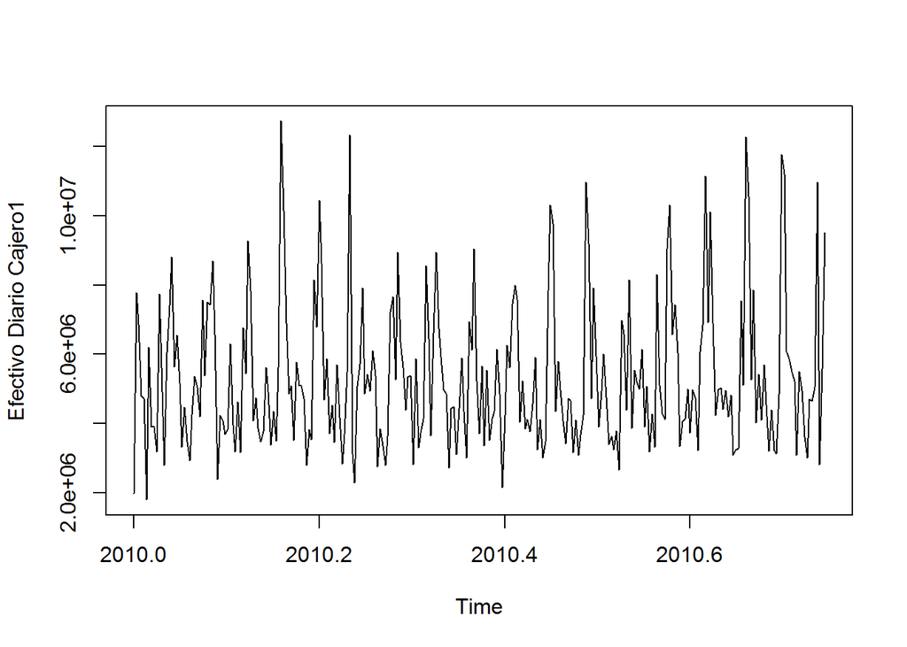

```r
#Grafico de las series de tiempo
plot(cajero1, ylab="Efectivo Diario Cajero1")
```

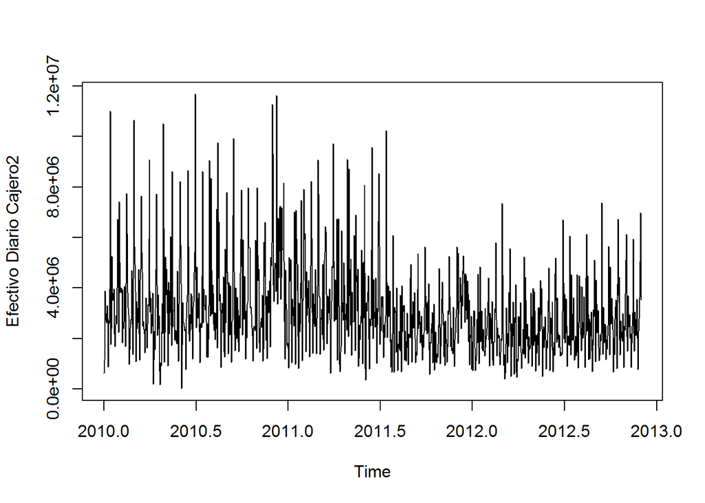

```r
plot(cajero2, ylab="Efectivo Diario Cajero2")
```

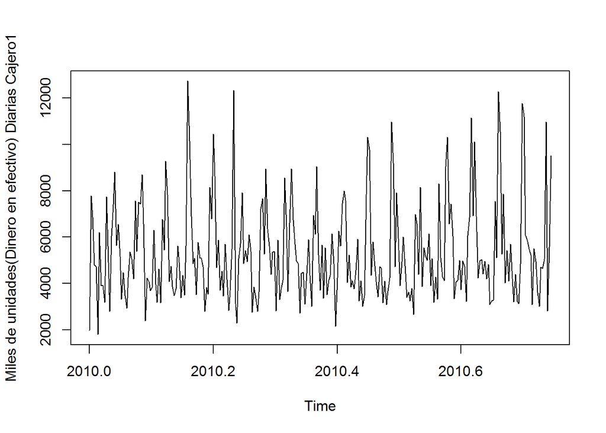

```r
plot(cajero1/1000, ylab="Miles de unidades(Dinero en efectivo) Diarias Cajero1")
```

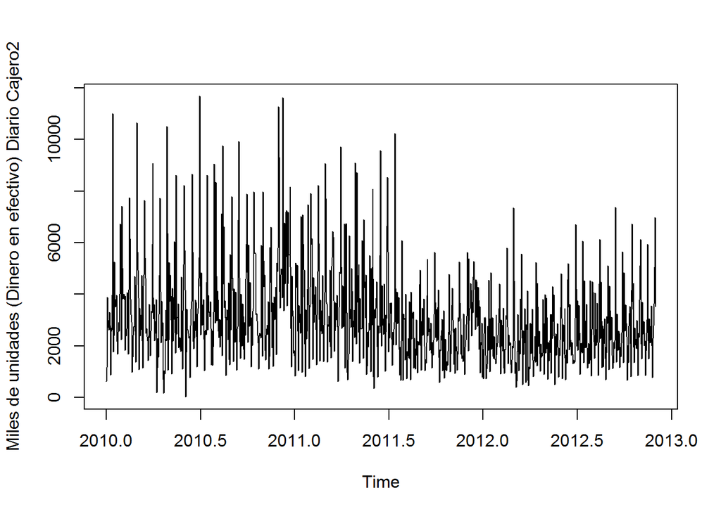

```r
plot(cajero2/1000, ylab="Miles de unidades (Dinero en efectivo) Diario Cajero2")
```

```r
cajero1 <- cajero1/1000
cajero2 <- cajero2/1000
```

En la gráfica de la serie de tiempo del cajero1, podemos darnos cuenta que no existen suficientes observaciones para completar un período. Además también se puede observar que los valores oscilan alrededor de un valor constante. Esto en principio, podría llevarnos a pensar que ambas series son estacionarias.

Los últimos 2 gráficos son las series pero esta vez todos sus valores fueron dividos entre mil (1000) con el fin de evitar errores por overflow en los análisis posteriores.

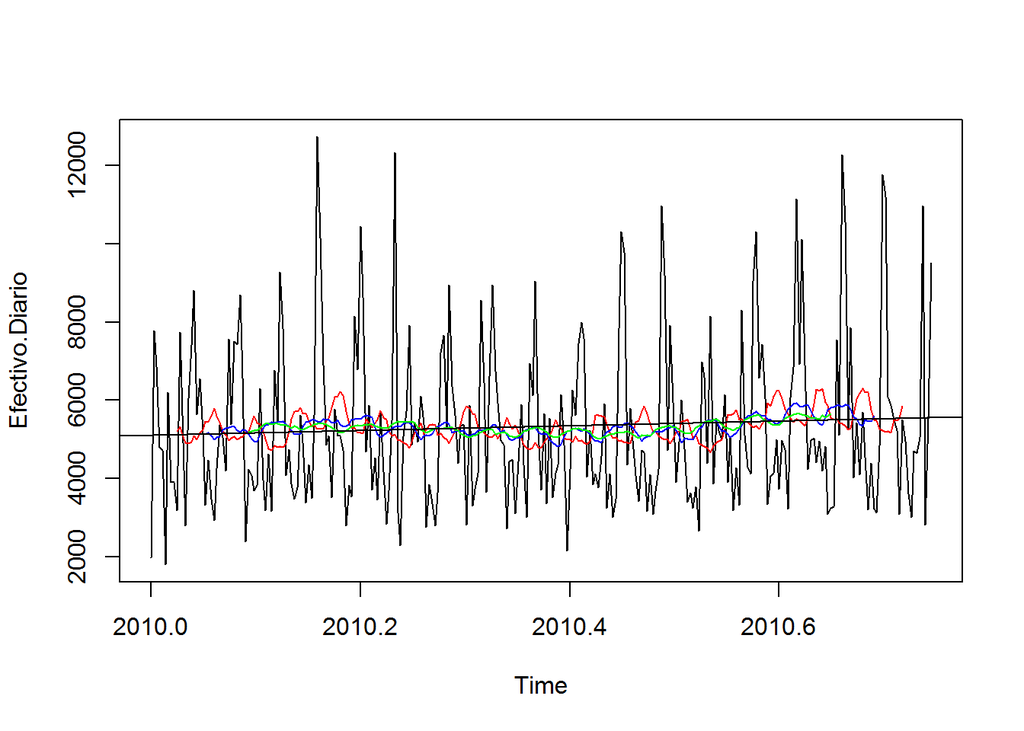

```r
#Diagnostico de la serie de tiempo cajero1

#Descomposicion de la serie de tiempo a traves de un suavizado

#Solo se obtuvo la tendencia, ya que la estacionalidad no fue posible
cajero1.filtro1 <- filter(cajero1, filter=rep(1/20, 20))
cajero1.filtro2 <- filter(cajero1, filter=rep(1/40, 40))
cajero1.filtro3 <- filter(cajero1, filter=rep(1/70, 70))
cajero1.lm <- lm(cajero1~time(cajero1))
plot(cajero1)
lines(cajero1.filtro1, col="red")
lines(cajero1.filtro2, col="blue")
lines(cajero1.filtro3, col="green")
abline(cajero1.lm)
```

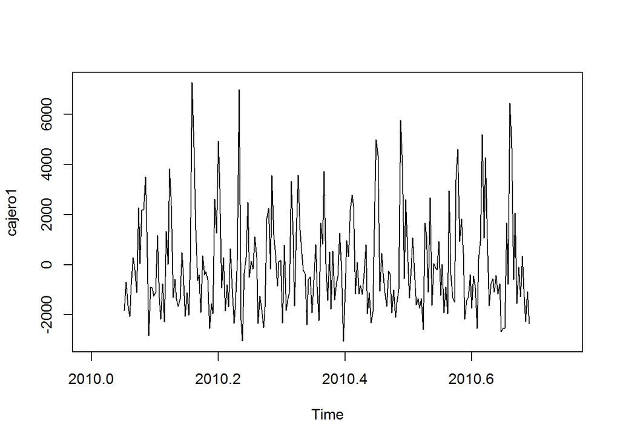

```r
#Residuales con variacion estacional
cajero1.residuals <- cajero1 - cajero1.filtro2
plot(cajero1.residuals)
```

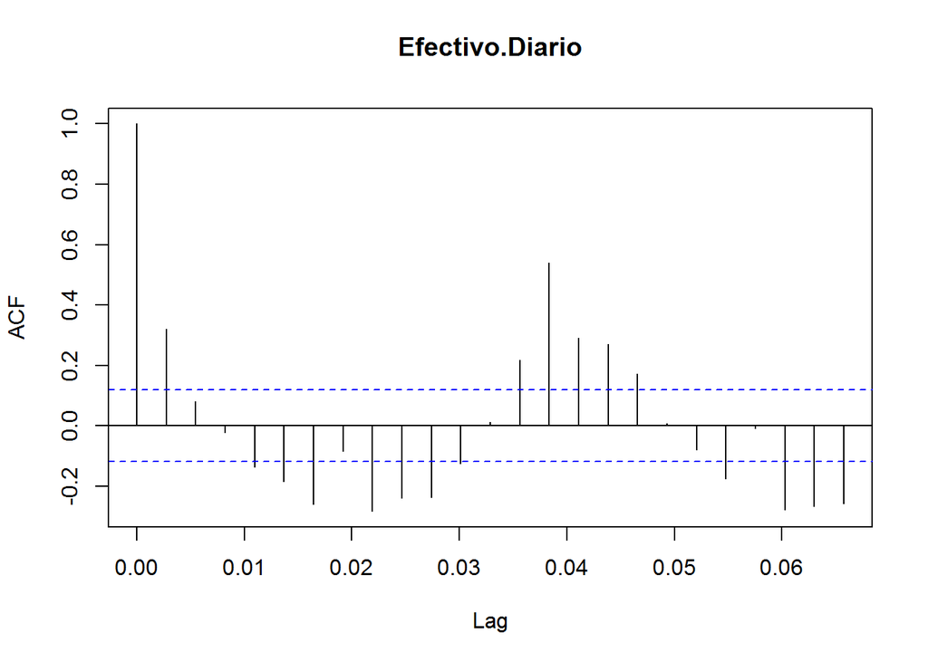

```r
#Correlacion Simple y parcial
acf(cajero1)
```

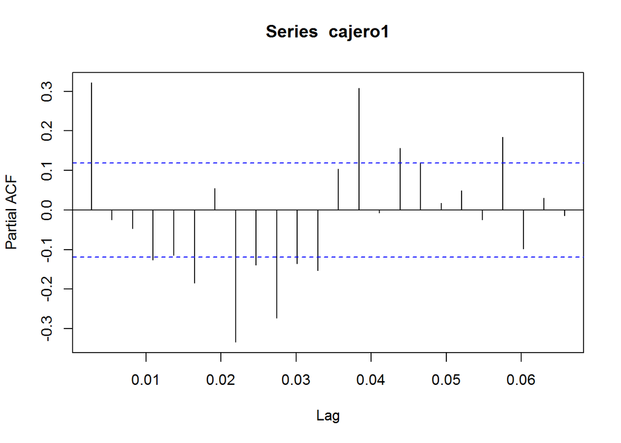

```r
pacf(cajero1)
```

```r
#Primeras diferencias del cajero1
adf.test(cajero1)
```

```
##
##  Augmented Dickey-Fuller Test
##
## data:  cajero1
## Dickey-Fuller = -7.4216, Lag order = 6, p-value = 0.01
## alternative hypothesis: stationary
```

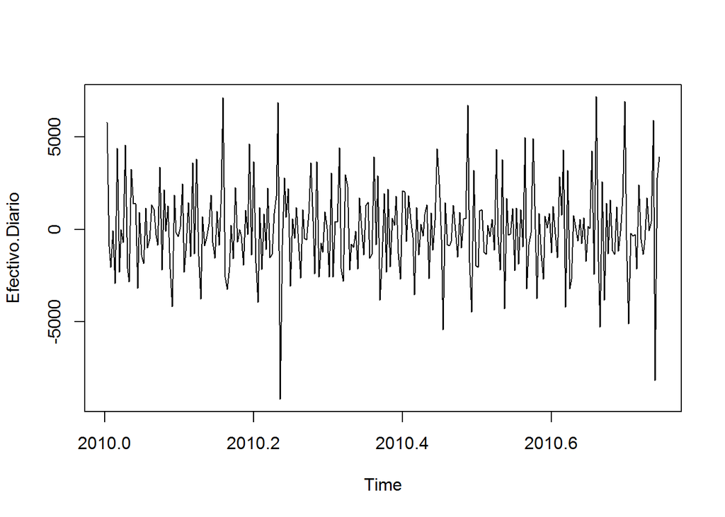

```r
cajero1.diffs1 = diff(cajero1)
plot(cajero1.diffs1)
```

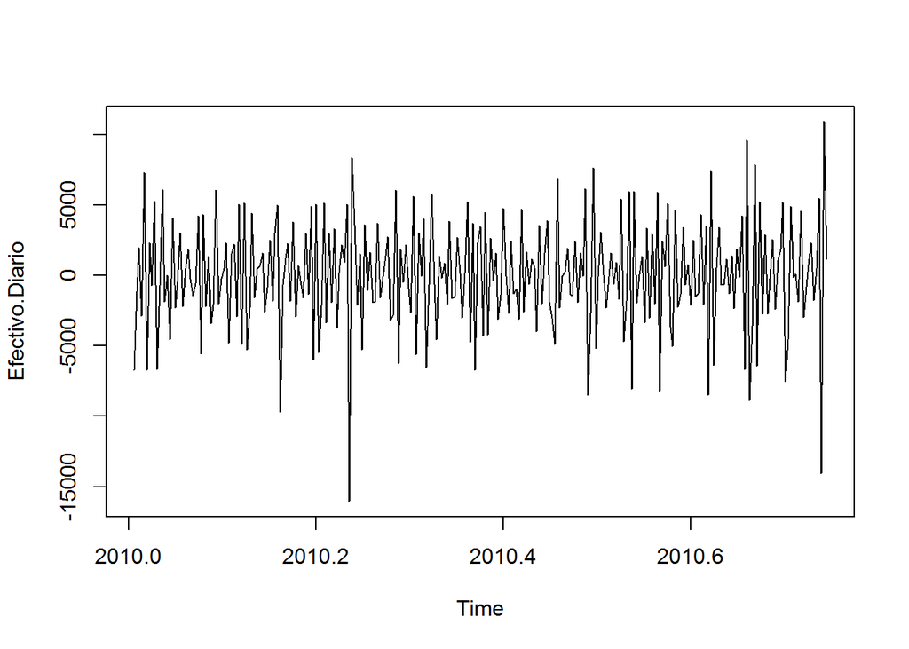

```r
cajero1.diffs2 = diff(cajero1.diffs1)
plot(cajero1.diffs2)
```

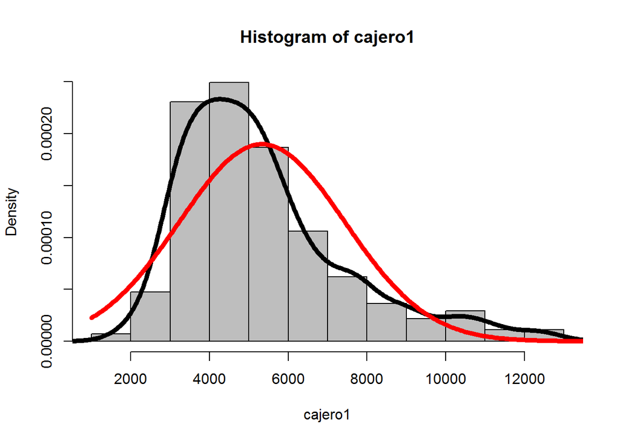

```r
#Test de normalidad
hist(cajero1, prob=T, col='grey')
mu.cajero1 = mean(cajero1)
sd.cajero1 = sd(cajero1)
lines(density(cajero1), lwd=5)
x <- seq(1000, 15000, length=273)
y<- dnorm(x, mu.cajero1, sd.cajero1)
lines(x,y,lwd=5,col='red')
```

```r
shapiro.test(cajero1)
```

```
##
##  Shapiro-Wilk normality test
##
## data:  cajero1
## W = 0.9077, p-value = 6.63e-12
```

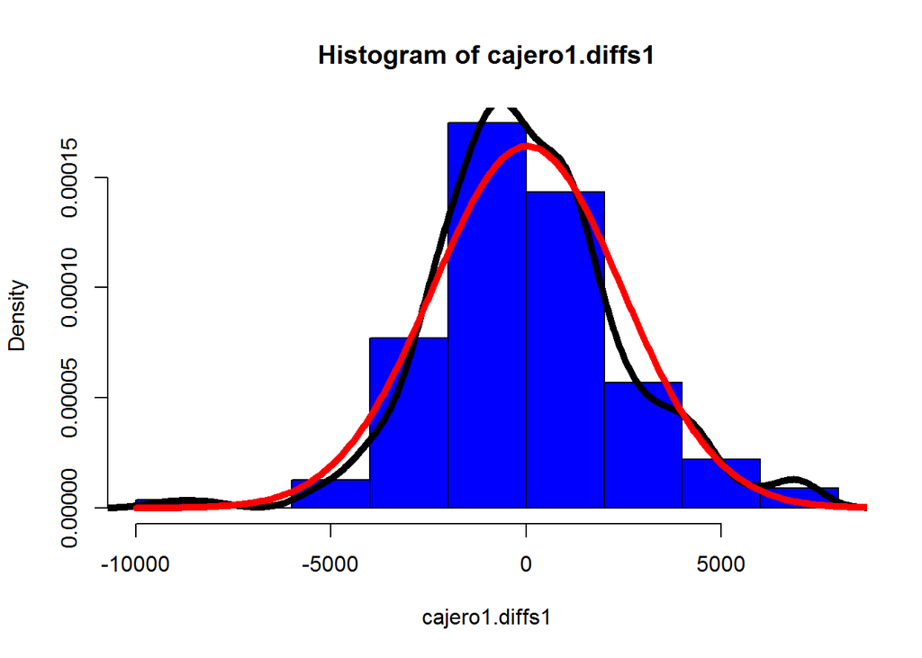

```r
hist(cajero1.diffs1, prob=T, col='blue')
mu.diffs1 = mean(cajero1.diffs1)
sd.diffs1 = sd(cajero1.diffs1)
lines(density(cajero1.diffs1), lwd=5)
x <- seq(-10000,10000, length=273)
y<- dnorm(x, mu.diffs1, sd.diffs1)
lines(x,y,lwd=5,col='red')
```

```r
shapiro.test(cajero1.diffs1)
```

```
##
##  Shapiro-Wilk normality test
##
## data:  cajero1.diffs1
## W = 0.9794, p-value = 0.000573
```

```r
#Peridiograma del cajero 1
cajero1.peridiograma <- spec.pgram(cajero1)
plot(cajero1.peridiograma)
cajero1.peridiograma$freq
```

```
##   [1]   1.267361   2.534722   3.802083   5.069444   6.336806   7.604167
##   [7]   8.871528  10.138889  11.406250  12.673611  13.940972  15.208333
##  [13]  16.475694  17.743056  19.010417  20.277778  21.545139  22.812500
##  [19]  24.079861  25.347222  26.614583  27.881944  29.149306  30.416667
##  [25]  31.684028  32.951389  34.218750  35.486111  36.753472  38.020833
##  [31]  39.288194  40.555556  41.822917  43.090278  44.357639  45.625000
##  [37]  46.892361  48.159722  49.427083  50.694444  51.961806  53.229167
##  [43]  54.496528  55.763889  57.031250  58.298611  59.565972  60.833333
##  [49]  62.100694  63.368056  64.635417  65.902778  67.170139  68.437500
##  [55]  69.704861  70.972222  72.239583  73.506944  74.774306  76.041667
##  [61]  77.309028  78.576389  79.843750  81.111111  82.378472  83.645833
##  [67]  84.913194  86.180556  87.447917  88.715278  89.982639  91.250000
##  [73]  92.517361  93.784722  95.052083  96.319444  97.586806  98.854167
##  [79] 100.121528 101.388889 102.656250 103.923611 105.190972 106.458333
##  [85] 107.725694 108.993056 110.260417 111.527778 112.795139 114.062500
##  [91] 115.329861 116.597222 117.864583 119.131944 120.399306 121.666667
##  [97] 122.934028 124.201389 125.468750 126.736111 128.003472 129.270833
## [103] 130.538194 131.805556 133.072917 134.340278 135.607639 136.875000
## [109] 138.142361 139.409722 140.677083 141.944444 143.211806 144.479167
## [115] 145.746528 147.013889 148.281250 149.548611 150.815972 152.083333
## [121] 153.350694 154.618056 155.885417 157.152778 158.420139 159.687500
## [127] 160.954861 162.222222 163.489583 164.756944 166.024306 167.291667
## [133] 168.559028 169.826389 171.093750 172.361111 173.628472 174.895833
## [139] 176.163194 177.430556 178.697917 179.965278 181.232639 182.500000
```

```r
cajero1.peridiograma$spec
```

```
##   [1]   5487.36275   4829.94329   1250.53366   1192.18620   4034.00384
##   [6]   6137.59184    869.79626   1785.70265   1272.87244   1836.50811
##  [11]    904.05537   1219.68996   2434.33919   2966.91769  11800.41009
##  [16]  10724.94524  15281.44553  31372.47366 467513.48439   4307.15566
##  [21]  17496.65766  22616.14255  10418.42046   5864.89577  19212.39220
##  [26]   2405.84090   7979.25422   2471.30454   5720.59110   5567.31675
##  [31]   8828.26732   3895.75662   3189.76226   2239.47484   5015.81749
##  [36]   1784.26135  28332.82754  84525.54026   4214.47664    972.24142
##  [41] 129014.92729     34.97536  32285.40169   7590.05994  16729.00925
##  [46]   5954.31885  24435.95062   3716.14367   2052.13829   1599.04650
##  [51]   1133.06160   3057.20195   2577.61054  11831.80846  13493.83018
##  [56]    743.94940  16377.82715   8058.94921  20828.64908   8977.82841
##  [61]    648.21665   2204.04702   2823.78216  15077.70679  11862.02345
##  [66]  25468.03107    271.73361    738.06481   8524.61282    365.31293
##  [71]   3320.25173   3102.20723   2090.87057  11724.40594   2632.39894
##  [76]   9977.64722    770.75240   5603.77563   1228.37132    911.32940
##  [81]   3739.79916  95581.36770  14711.03005    217.59817  10522.38773
##  [86]  17502.53776   7038.17080    386.99968   1276.37344    384.15813
##  [91]   4832.48399    241.42773   2236.98466   6355.68973   3235.90010
##  [96]   4117.60731   1390.08804   2808.86915   9609.34625   3276.70075
## [101]   2264.40388   1296.37738   3921.54448   5025.10255  16688.11389
## [106]   3754.12603   6719.09299   1883.69931    324.61186  10951.25428
## [111]   1740.74086   1202.94350   4697.54854    795.21325   1859.96092
## [116]    406.59187   1444.13006   7173.18393   1061.66720    538.03811
## [121]   4554.30469  13215.56690  53535.89153  50199.80772  12565.13215
## [126]    538.75921   1463.46811    238.18081   4216.35960   3314.90868
## [131]    232.99975   6965.81040   3189.35238   2447.75994     72.92830
## [136]   7236.66783   5708.20744   2745.94808    837.19147   4183.97375
## [141]   2636.57434    498.87556     64.20656   3000.23523
```

```r
order(cajero1.peridiograma$spec, cajero1.peridiograma$freq, decreasing = TRUE)
```

```
##   [1]  19  41  82  38 123 124  43  18  37  66  47  22  59  25  86  21  45
##  [18] 105  57  17  64  83  55 122 125  65  54  15  74 110  16  85  23  76
##  [35]  99  60  31  69  58  27  44 136 118  87 132 107  94   6  46  24  29
##  [52] 137  78  30   1 104  35  91   2 113 121  20 129  39 140  96   5 103
##  [69]  32 106  81  48  71 130 100  95  33 133  72  52 144  14  63  98 138
##  [86] 141  75  53  28 134  13  26 101  34  93  62  73  49 108 115  10   8
## [103]  36 111  50 127 117  97 102  89   9   3  79  12 112   4  51 119  40
## [120]  80  11   7 139 114  77  56  68  61 126 120 142 116  88  90  70 109
## [137]  67  92 128 131  84 135 143  42
```

```r
max1 <- cajero1.peridiograma$freq[19]
max1
```

```
## [1] 24.07986
```

```r
max2 <- cajero1.peridiograma$freq[41]
max2
```

```
## [1] 51.96181
```

```r
max3 <- cajero1.peridiograma$freq[82]
max3
```

```
## [1] 103.9236
```

```r
abline(v = max1, lty = "dotted", col = "red")
abline(v = max2, lty = "dotted", col = "blue")
abline(v = max3, lty = "dotted", col = "green")
periodo1 <- 365/max1
periodo1
```

```
## [1] 15.15789
```

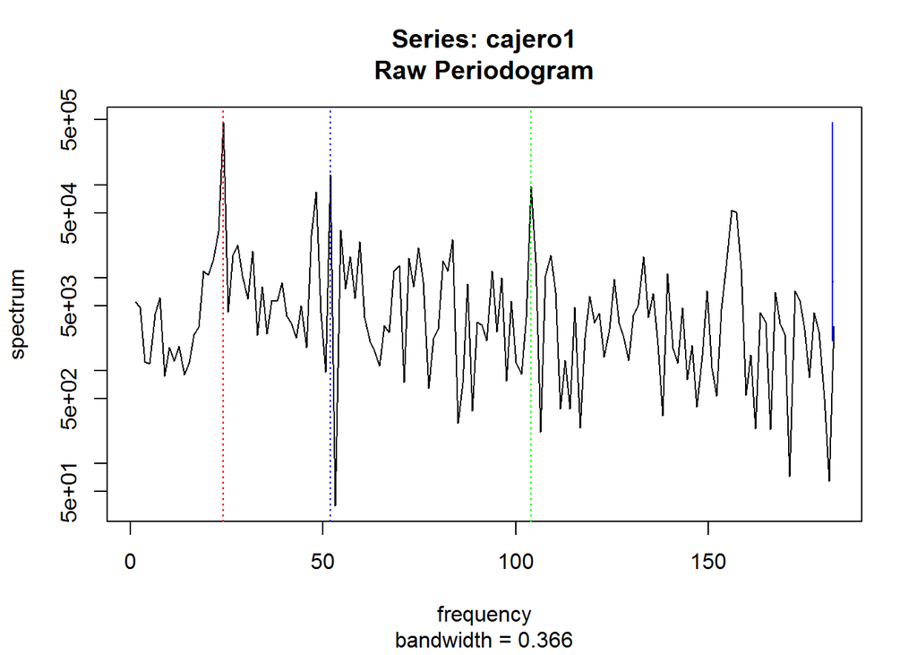

```r
abline(v = max2, lty = "dotted", col = "blue")
```

```r
periodo2 <- 365/max2
periodo2
```

```
## [1] 7.02439
```

```r
periodo3 <- 365/max3
periodo3
```

```
## [1] 3.512195
```

Claramente, la serie cajero1, no contiene suficientes observaciones para estudiar algun tipo de variación estacional, sin embargo, se evidencia que existe cierta ciclicidad en las observaciones (R contempla la variación cíclica dentro del componente de variación estacional) de modo que asumiremos que tiene variación cíclica.

Los gráficos de correlación simple y parcial, denotan que la correlación entre una obsevación y otra oscila alrededor de 0. En base esto podriamos inferir que estamos en presencia de un proceso de medias moviles autorregresivo (ARMA).

En el peridiograma, se observó que los periodos mas importantes son 15, 7 y 3, aproximadamente.

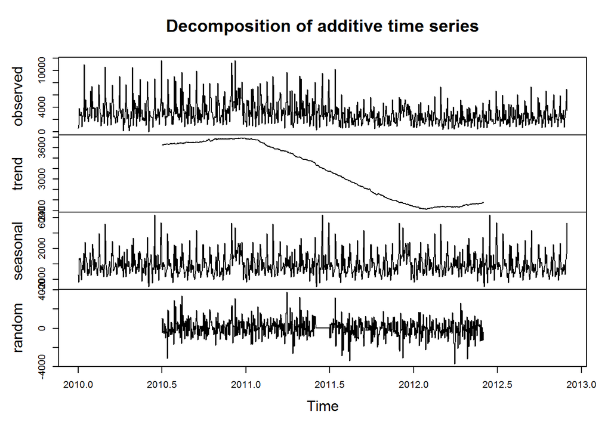

```r
#Diagnostico de la serie de tiempo cajero2

#Descomposicion de la serie de tiempo (Modelo aditivo)
cajero2.add <- decompose(cajero2)
plot(cajero2.add)
```

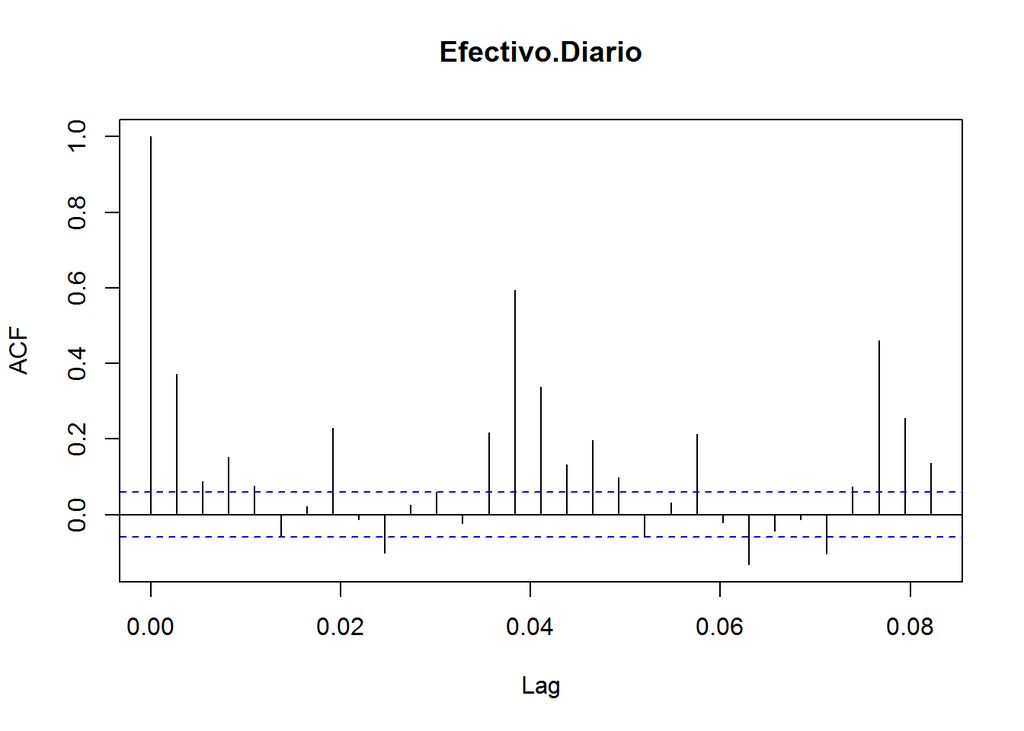

```r
#Correlacion Simple y Parcial del cajero2
acf(cajero2)
```

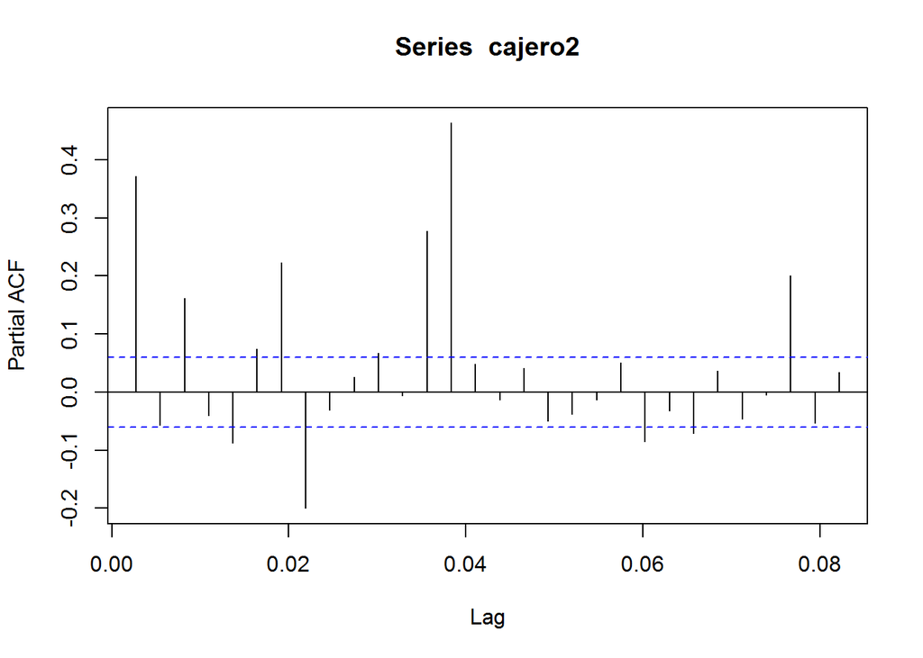

```r
pacf(cajero2)
```

```r
#Primeras Diferencias del cajero 2
adf.test(cajero2)
```

```
##
##  Augmented Dickey-Fuller Test
##
## data:  cajero2
## Dickey-Fuller = -10.5582, Lag order = 10, p-value = 0.01
## alternative hypothesis: stationary
```

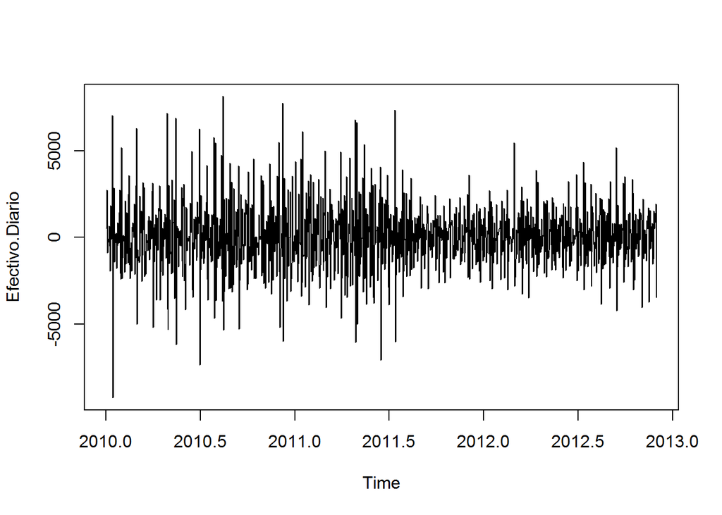

```r
cajero2.diffs1 = diff(cajero2)
plot(cajero2.diffs1)
```

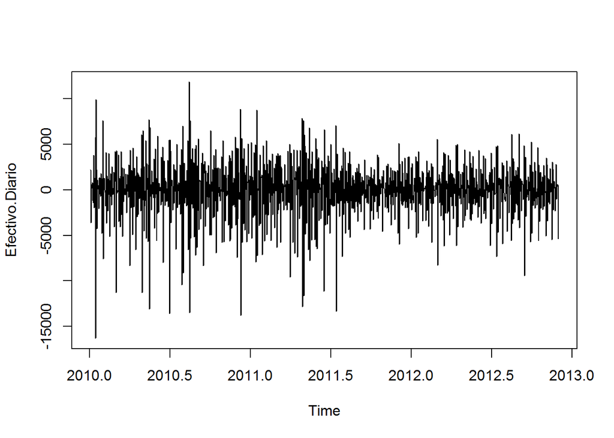

```r
cajero2.diffs2 = diff(cajero2.diffs1)
plot(cajero2.diffs2)
```

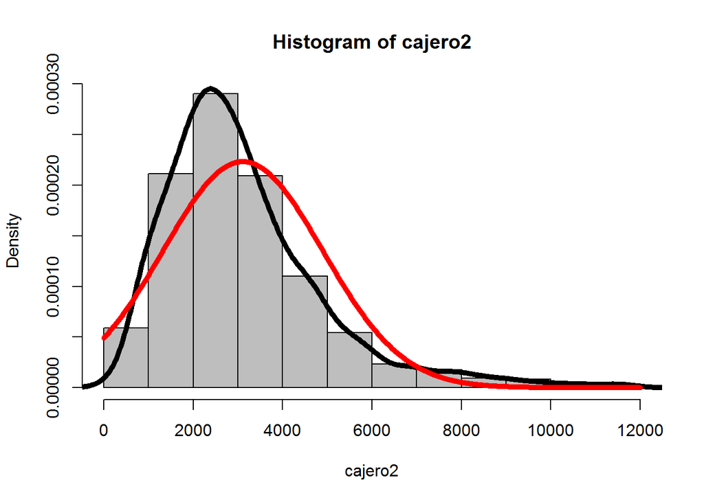

```r
#Test de normalidad del cajero2
hist(cajero2, prob=T, col='grey')
mu.cajero2 = mean(cajero2)
sd.cajero2 = sd(cajero2)
lines(density(cajero2), lwd=5)
x <- seq(0, 12000, length=length(cajero2))
y<- dnorm(x, mu.cajero2, sd.cajero2)
lines(x,y,lwd=5,col='red')
```

```r
shapiro.test(cajero2)
```

```
##
##  Shapiro-Wilk normality test
##
## data:  cajero2
## W = 0.8958, p-value < 2.2e-16
```

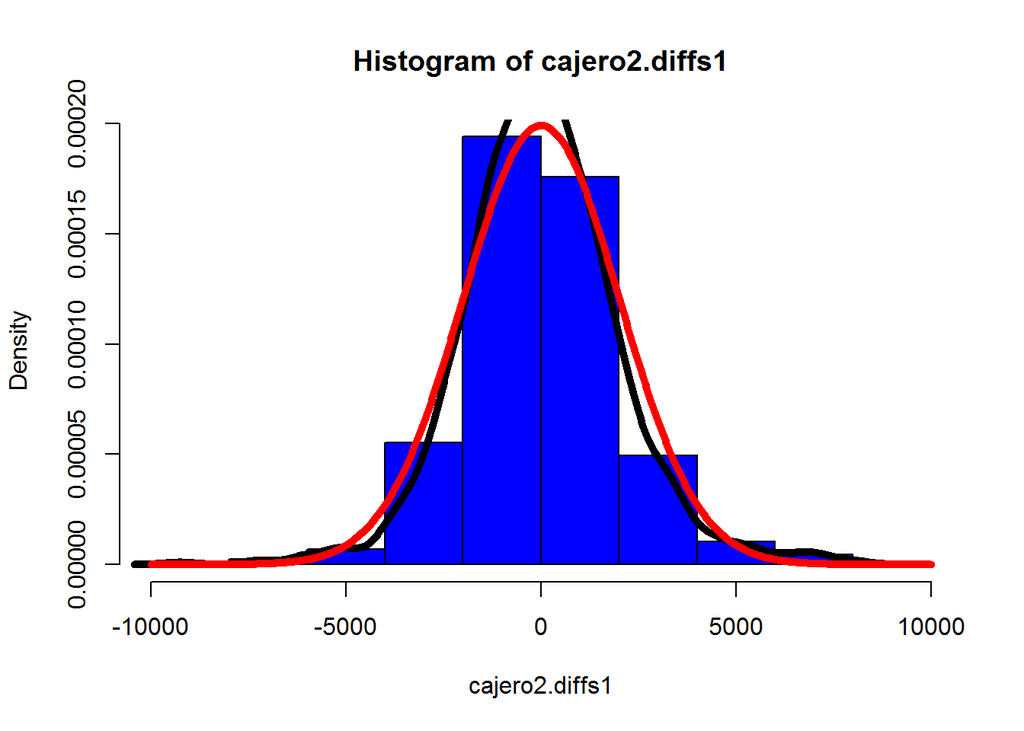

```r
hist(cajero2.diffs1, prob=T, col='blue')
mu.diffs1 = mean(cajero2.diffs1)
sd.diffs1 = sd(cajero2.diffs1)
lines(density(cajero2.diffs1), lwd=5)
x <- seq(-10000,10000, length=length(cajero2))
y<- dnorm(x, mu.diffs1, sd.diffs1)
lines(x,y,lwd=5,col='red')
```

```r
shapiro.test(cajero2.diffs1)
```

```
##
##  Shapiro-Wilk normality test
##
## data:  cajero2.diffs1
## W = 0.9799, p-value = 5.81e-11
```

```r
#Peridiograma del Cajero 2
cajero2.peridiograma <- spec.pgram(cajero2)
plot(cajero2.peridiograma)
cajero2.peridiograma$freq
```

```
##   [1]   0.3379630   0.6759259   1.0138889   1.3518519   1.6898148
##   [6]   2.0277778   2.3657407   2.7037037   3.0416667   3.3796296
##  [11]   3.7175926   4.0555556   4.3935185   4.7314815   5.0694444
##  [16]   5.4074074   5.7453704   6.0833333   6.4212963   6.7592593
##  [21]   7.0972222   7.4351852   7.7731481   8.1111111   8.4490741
##  [26]   8.7870370   9.1250000   9.4629630   9.8009259  10.1388889
##  [31]  10.4768519  10.8148148  11.1527778  11.4907407  11.8287037
##  [36]  12.1666667  12.5046296  12.8425926  13.1805556  13.5185185
##  [41]  13.8564815  14.1944444  14.5324074  14.8703704  15.2083333
##  [46]  15.5462963  15.8842593  16.2222222  16.5601852  16.8981481
##  [51]  17.2361111  17.5740741  17.9120370  18.2500000  18.5879630
##  [56]  18.9259259  19.2638889  19.6018519  19.9398148  20.2777778
##  [61]  20.6157407  20.9537037  21.2916667  21.6296296  21.9675926
##  [66]  22.3055556  22.6435185  22.9814815  23.3194444  23.6574074
##  [71]  23.9953704  24.3333333  24.6712963  25.0092593  25.3472222
```

[output cut: 93 more lines]

```r
cajero2.peridiograma$spec
```

```
##   [1] 9.404732e+04 1.141585e+05 1.574252e+04 6.407069e+03 5.556253e+03
##   [6] 2.783303e+04 1.309262e+04 4.410116e+03 6.384822e+03 1.746501e+03
##  [11] 1.388540e+04 1.572632e+04 5.762641e+03 8.968204e+03 3.958944e+04
##  [16] 1.264862e+04 7.706188e+03 8.898698e+03 6.333772e+03 2.453451e+04
##  [21] 2.231481e+04 7.373519e+02 4.103134e+03 9.853921e+03 1.088163e+03
##  [26] 1.058681e+04 4.437709e+03 2.704237e+03 1.009156e+04 9.837636e+03
##  [31] 1.056326e+03 1.936313e+03 1.163005e+04 2.622600e+02 1.687347e+04
##  [36] 8.484015e+02 4.316086e+03 4.383856e+03 3.388277e+03 6.239781e+02
##  [41] 3.148246e+03 1.489607e+04 3.923021e+03 6.468657e+02 2.724413e+03
##  [46] 3.031646e+02 1.429293e+03 3.570959e+02 1.032311e+03 7.667300e+03
##  [51] 2.472981e+03 1.000710e+04 6.017197e+03 1.542062e+03 2.554737e+02
##  [56] 2.799379e+03 1.992894e+03 7.397204e+02 1.645959e+03 4.390370e+02
##  [61] 2.777503e+03 6.938853e+03 4.819338e+03 3.020351e+03 2.738180e+03
##  [66] 4.488775e+03 1.004439e+03 6.018102e+04 2.366208e+04 4.239423e+04
##  [71] 5.803227e+05 1.947452e+04 2.668760e+03 2.858262e+04 3.228660e+03
```

[output cut: 93 more lines]

```r
order(cajero2.peridiograma$spec, cajero2.peridiograma$freq, decreasing = TRUE)
```

```
##   [1]  71 154 309 308 463   2 142   1 155 225  68  70  15  80  74 423 311
##  [18]   6 145 379 392  20 226 156  69  21 307 139 213  72 240 249  35 381
##  [35] 317   3  12  92  42  77 380  11 460  90 190   7  16  93 462  81 310
##  [52] 296  86 151 321  33 218 216 281 227 451 141  26  29 220 485  52 494
##  [69] 343 176  24  30  82 189 234 377 206  91  14 108  18 254 198 152 468
##  [86] 160 297 143 109  17  50  98 114 140 339 454 202 506 383  99  62 224
## [103] 278 338 284 306 207 250 483 162 452   4 389   9 158 358  19 235  76
## [120]  85 197 280  53 512 429 320 195 484  13 352 103 510   5 329 153 290
## [137] 175 169 247 136 127 119 233 450 312 330 464 258 325  63 124 231 133
## [154] 194 262 147 135 476 368 174 391  66 294  27   8 223  38 138  37 394
## [171] 269  87 516 150 432  23 295 117 374 435 386 351  43 340 342 163 130
## [188] 382 123 193 219 276 246 105 467 212 149  78 534 370 395 196 488 345
## [205] 268 267  39 536 283 170 228 497 256 361 316  75 417 186 418 232 479
## [222] 428 436  41 350 465 348 526 466  64 335 255 390  95 236 519 128 188
## [239] 459 430 115 388 503  97  56 507  61 401 288  65  45 414  28 217 245
```

[output cut: 17 more lines]

```r
max1 <- cajero2.peridiograma$freq[71]
max1
```

```
## [1] 23.99537
```

```r
max2 <- cajero2.peridiograma$freq[154]
max2
```

```
## [1] 52.0463
```

```r
max3 <- cajero2.peridiograma$freq[309]
max3
```

```
## [1] 104.4306
```

```r
abline(v = max1, lty = "dotted", col = "red")
abline(v = max2, lty = "dotted", col = "blue")
abline(v = max3, lty = "dotted", col = "green")
periodo1 <- 365/max1
periodo1
```

```
## [1] 15.21127
```

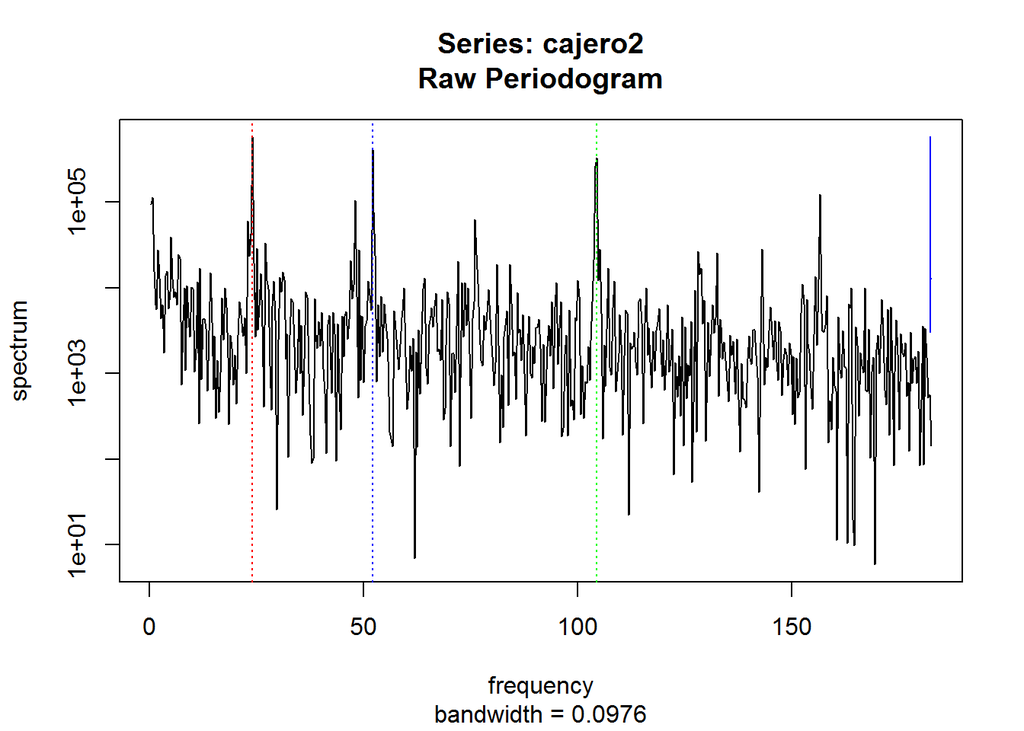

```r
abline(v = max2, lty = "dotted", col = "blue")
```

```r
periodo2 <- 365/max2
periodo2
```

```
## [1] 7.012987
```

```r
periodo3 <- 365/max3
periodo3
```

```
## [1] 3.495146
```

En cuanto a la serie de tiempo cajero2, podemos decir que se comporta de una manera similar a la serie cajero1. Es importante destacar que estamos en presencia de 2 series de tiempo que tienen almacenado cuanto efectivo se retira de 2 cajeros automáticos de algún país, de algún banco. Sabiendo esto, tiene un sentido que las series sean similares.

En la serie de tiempo cajero2 si fue posible obtener el componente de variación estacional, ya que existen suficientes observaciones para la descomposición de la serie en un modelo aditivo.

Al igual que el cajero1 se observó que los periodos mas importantes son 15, 7 y 3, aproximadamente.

```r
#### Eleccion de Modelos ####
best.order <- c(0, 0, 0)
best.aic <- 9999999999
for( i in 0:3 ){
  for( j in 0:3 ){
    fit.aic <- AIC(arima(cajero1, order=c(i,0,j), method="ML"))
    if( fit.aic < best.aic )
    {
      best.order = c(i,0,j)
      cajero1.best.arma = arima(cajero1, order=best.order)
      best.aic = fit.aic
    }

  }
}
best.order <- c(0, 0, 0)
best.aic <- 99999999999
for( i in 0:3 ){
  for( j in 0:3 ){
    fit.aic <- AIC(arima(cajero2, order=c(i,0,j), method="ML"))
    if( fit.aic < best.aic )
    {
      best.order = c(i,0,j)
      cajero2.best.arma = arima(cajero2, order=best.order, method="ML")
      best.aic = fit.aic
    }

  }
}
```

Se eligieron 2 modelos ARMA diferentes, uno ARMA(2,2) y el otro ARMA(3,2) para las series cajero1 y cajero2, respectivamente. Para la elección del orden, se utilizó el método de máxima similitud acompanado del índice de información de Akaike.

```r
#### Calculo del Error ####

cajero1.best.arma
```

```
##
## Call:
## arima(x = cajero1, order = best.order)
##
## Coefficients:
##          ar1      ar2      ma1     ma2  intercept
##       1.8269  -0.9927  -1.8689  0.9999  5333.0383
## s.e.  0.0059   0.0055   0.0219  0.0231    82.0801
##
## sigma^2 estimated as 2942673:  log likelihood = -2424.93,  aic = 4861.86
```

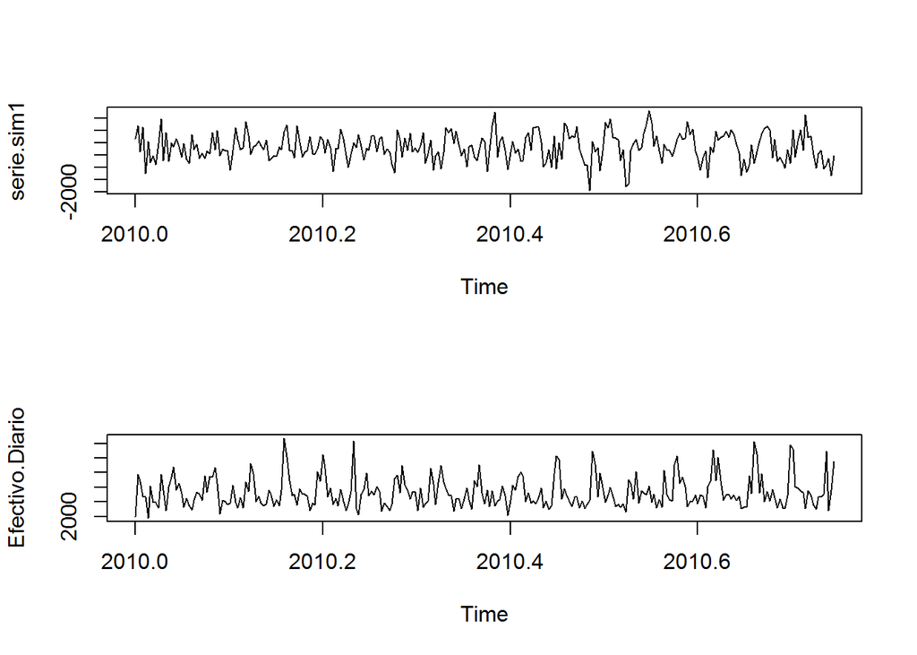

```r
serie.sim1 <- simulate(cajero1.best.arma, future=FALSE, seed=666)
layout(1:2)
plot(serie.sim1)
plot(cajero1)
```

```r
residuals <- ER(serie.sim1, cajero2)
residuals
```

```
## [1] 0.2291394
```

```r
cajero2.best.arma
```

```
##
## Call:
## arima(x = cajero2, order = best.order, method = "ML")
##
## Coefficients:
##          ar1      ar2     ar3     ma1     ma2  intercept
##       0.0251  -0.7910  0.4698  0.4382  0.9965  3128.1297
## s.e.  0.0272   0.0121  0.0272  0.0041  0.0063    84.6448
##
## sigma^2 estimated as 2164814:  log likelihood = -9282.92,  aic = 18579.84
```

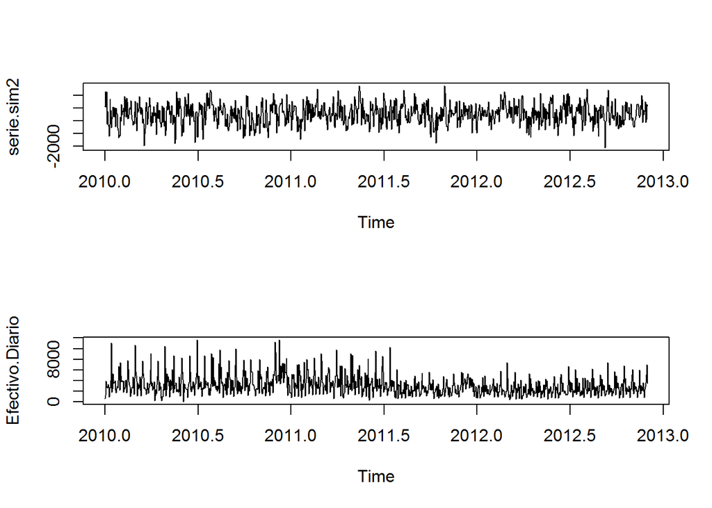

```r
serie.sim2 <- simulate(cajero2.best.arma, future=FALSE, seed=666)
plot(serie.sim2)
plot(cajero2)
```

```r
residuals <- ER(serie.sim2, cajero2 )
residuals
```

```
## [1] 0.6049251
```

```r
layout(1:1)
```

```r
#### Prediccion ####
cajero1.prediccion <- forecast.Arima(cajero1.best.arma, h = 14)
cajero1.prediccion
```

```
##          Point Forecast    Lo 80    Hi 80      Lo 95     Hi 95
## 2010.748       7208.283 5001.943 9414.624 3833.97733 10582.590
## 2010.751       6696.151 4488.476 8903.825 3319.80424 10072.498
## 2010.753       5961.786 3749.601 8173.972 2578.54039  9345.032
## 2010.756       5128.555 2908.929 7348.181 1733.93016  8523.180
## 2010.759       4335.311 2107.440 6563.181  928.07639  7742.545
## 2010.762       3713.263 1478.953 5947.573  296.18064  7130.345
## 2010.764       3364.283 1126.780 5601.786  -57.68235  6786.248
## 2010.767       3344.228 1106.175 5582.282  -78.57911  6767.036
## 2010.770       3654.021 1415.821 5892.221  230.99022  7077.052
## 2010.773       4239.894 1999.515 6480.273  813.52990  7666.258
## 2010.775       5002.705 2757.026 7248.385 1568.23460  8437.176
## 2010.778       5814.705 3561.539 8067.870 2368.78574  9260.624
## 2010.781       6540.922 4280.408 8801.436 3083.76479  9998.079
## 2010.784       7061.593 4796.077 9327.110 3596.78457 10526.402
```

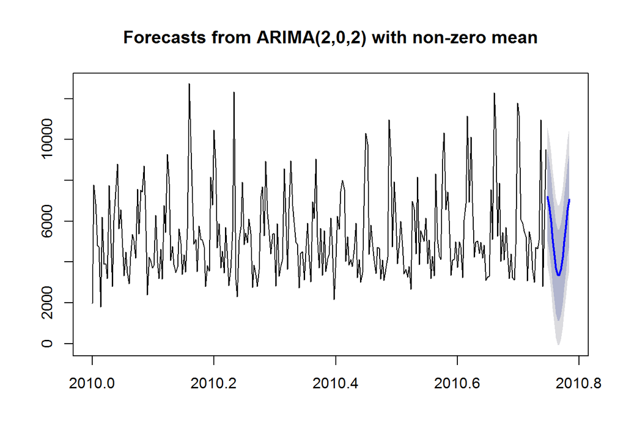

```r
plot.forecast(cajero1.prediccion)
```

```r
cajero2.prediccion <- forecast.Arima(cajero2.best.arma, h = 14)
cajero2.prediccion
```

```
##          Point Forecast     Lo 80    Hi 80     Lo 95    Hi 95
## 2012.918       2622.476  736.7318 4508.221 -261.5210 5506.474
## 2012.921       3714.537 1636.2285 5792.846  536.0384 6893.036
## 2012.923       3727.378 1609.1662 5845.590  487.8525 6966.904
## 2012.926       2441.799  313.6803 4569.918 -812.8777 5696.476
## 2012.929       2912.390  782.2880 5042.492 -345.3200 6170.101
## 2012.932       3947.097 1816.7500 6077.445  689.0122 7205.183
## 2012.934       2996.913  866.4260 5127.400 -261.3858 6255.212
## 2012.937       2375.703  245.1382 4506.268 -882.7148 5634.121
## 2012.940       3597.761 1467.1928 5728.328  339.3383 6856.183
## 2012.942       3673.428 1542.8587 5803.998  415.0033 6931.853
## 2012.945       2416.881  286.2810 4547.481 -841.5905 5675.353
## 2012.948       2899.577  768.9779 5030.177 -358.8934 6158.048
## 2012.951       3941.140 1810.5151 6071.765  682.6303 7199.650
## 2012.953       2995.192  864.5631 5125.821 -263.3237 6253.708
```

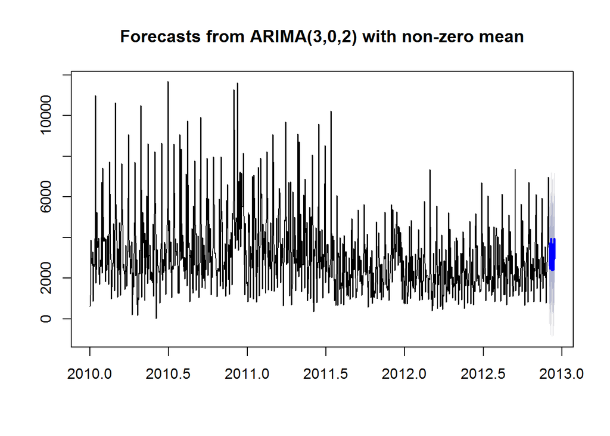

```r
plot.forecast(cajero2.prediccion)
```

Para finalizar, se realizó una predicción de 14 días (2 semanas) y se graficaron los resultados.